# Štatistické metódy vyhodnocovania experimentov

11. Logistická regresia

Tomáš Bacigál

4.5.2021

```r
`%>%` <- magrittr::`%>%`  # pipe operator
library(ggplot2)
```

# Modelovanie závislosti

## Odozva (A) je diskrétna (ordinálna alebo kvalitatívna) náhodná premenná

Model závislosti diskrétnej náhodnej premennej (od prediktorov ľubovoľného typu) je podstatne komplikovanejší než v predošlých prípadoch, keď odozva bola spojitá (a ešte aj normálne rozdelená). Voľba štatistickej metódy závisí od  
- počtu hodnôt (úrovní, tried) premennej,  
- existencie poradia hodnôt,  
- znalosti rozdelenia pravdepodobnosti.

Pre binárnu (dvojhodnotovú) premennú je vhodný zovšeobecnený lineárny model s binomickým rozdelením a najčastejšie s *logit link* funkciou (tzv. logistická regresia). Pri viachodnotových premenných sa používa ordinálna logistický regresia (ak je poradie tried odozvy dané) alebo multinomická logistická regresia (bez definovaného poradia hodnôt), alternatívne lineárna diskriminačná analýza (filozoficky úplne odlišná od logistickej regresie, a vyžaduje striktnejšie predpoklady).

### Odozva je binárna premenná -> Logistická regresia

**Pozn.:** Logistická regresia je špeciálnym prípadom *zovšeobecneného lineárneho modelu*

$g(A) = b_0 + b_1 X + ε$

Zatiaľ čo lineárny model predpokladá

- lineárny vzťah medzi strednou hodnotou odozvy (vysvetľovanej premennej) a prediktormi,
- normálne rozdelenie odozvy,
- nezávislosť náhodnej zložky ε,

zovšeobecnený lineárny model má prvé dva predpoklady voľnejšie:

- odozva transformovaná link funkciou *g* je lineárnou kombináciou prediktorov,
- odozva môže mať ľubovoľné rozdelenie z exponenciálnej triedy rozdelení (normálne, binomické, poissonovo, beta, …)

**Príklad:** Odhadnime typ prevodovky…

#### Jeden prediktor

```r
plot(am ~ mpg, data = mtcars)
```

Problém odhadu strednej hodnoty kvalitatívnej premennej Y sa prirodzene zvrtne na problém odhadu strednej hodnoty pravdepodobnosti, že Y nadobudne konkrétnu hodnotu. Pravdepodobnosť je už spojitá a dá sa modelovať lineárnym modelom $p = b_0 + b_1 X$

```r
fit1 <- lm(am ~ mpg, data = mtcars)
```

```r
lines(mtcars$mpg, fit1$fitted.values)
```

No taký model má viditeľné nedostatky - prekračuje hranice jednotkového intervalu. Na skrotenie použijeme exponenciálnu funkciu, ktorej hodnoty sú vždy nad nulou, a vydelíme ju jej hodnotou len o jedna väčšou, aby sme dostali číslo menšie ako 1, čiže $p = e^{b_0 + b_1 X}/{1+e^{b_0 + b_1 X}}$, napr.

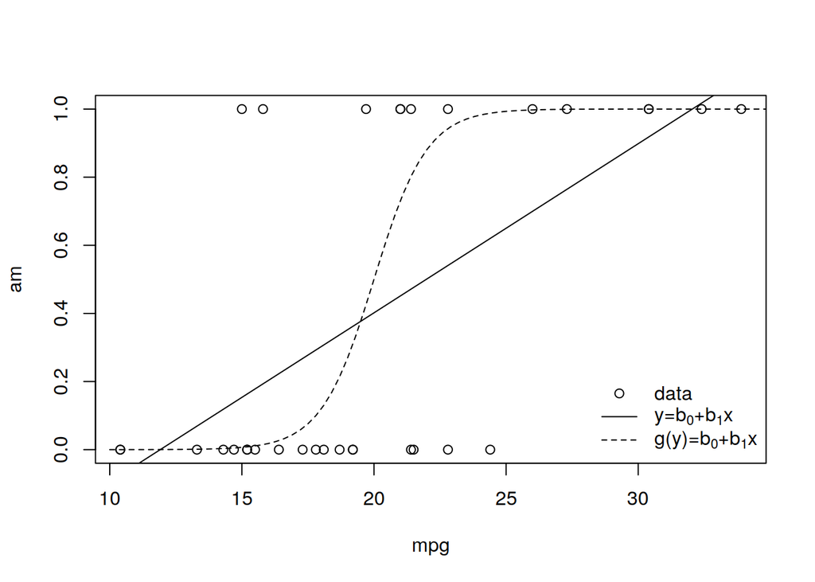

```r
curve(exp(x-20) / (1+exp(x-20)), from=10, to=40, add=TRUE, lty=2)
```

Úpravou podielu p/(1-p), ktorý predstavuje tzv. šancu (pravdepodobnosť úspechu ku pravdepodobnosti neúspechu, angl. *odds ratio*), dostávame model $log(p/{1-p})=b_0+b_1 X$ lineárny v parametroch, ktorý na ľavej strane obsahuje link funkciu $g(x)=log(x/{1-x})$, konkrétne tzv. *logit link* funkciu. Odhad parametrov už nejde vykonať bežnou metódou najmenších štvorcov tak ako pri lineárnom modeli, a tak sa používa metóda maximálnej vierohodnosti, čiže maximalizovanie vierohodnostnej funkcie $L(b_0,b_1)=\Pi_i p(x_i)^{y_i}[1-p(x_i)]^{1-y_i}$ (predpokladajúc kódovanie Y = 0 alebo 1). Keďže stredná hodnota je pravdepodobnosť ktorú môžeme reprezentovať počtom priaznivých ku (konečnému) počtu všetkých udalostí, použije sa binomické rozdelenie.

```r
( fit2 <- glm(am ~ mpg, data = mtcars, family = binomial(link="logit")) )
```

```
##
## Call:  glm(formula = am ~ mpg, family = binomial(link = "logit"), data = mtcars)
##
## Coefficients:
## (Intercept)          mpg
##      -6.604        0.307
##
## Degrees of Freedom: 31 Total (i.e. Null);  30 Residual
## Null Deviance:       43.23
## Residual Deviance: 29.68     AIC: 33.68
```

Výstup *glm* obsahuje parametre $b_0=-6.6035$, $b_1=0.307$, potom tzv. *null deviance* a *residual deviance*. Deviancia *D* je rozdiel medzi log-vierohodnostnými funkciami saturovaného modelu (dokonale priliehajúceho dátam) a odhadnutého modelu. A keďže likelihood funkcia saturovaného modelu je rovná jednej, jej logaritmus nulový, potom residual deviance $D = -2 \log L(\hat{b}_0, \hat{b}_1)$ je vždy väčšia ako nula, nanajvýš rovná nule (ak je model dokonalý). Naproti tomu null deviance je referenčnou hodnotou zodpovedajúcou základnému modelu (bez prediktorov) $D_0 = -2 \log L(\hat{b}_0|b_1=0)$. Akaikeho informačné kritérium AIC je iba miera vychádzajúca z deviancie a penalizujúca zložitejšie modely, $AIC = D + 2k$, kde *k* je počet parametrov modelu, v prípade *fit2* to bude $k=2$. Preferujeme model s čo najnižším AIC.

```r
# manuálny výpočet deviancií:
#p <- function(x, pars) c( exp(cbind(1,x) %*% pars) / (1+exp(cbind(1,x) %*% pars)) )
#fit0 <- glm(am ~ 1, data = mtcars, family = binomial(link="logit"))
#c(D = -2*sum(log( p(mtcars$mpg, fit2$coefficients)^mtcars$am * (1-p(mtcars$mpg, fit2$coefficients))^(1-mtcars$am) )),
#  D0 = -2*sum(log( p(mtcars$mpg, c(fit0$coefficients,0))^mtcars$am * (1-p(mtcars$mpg, c(fit0$coefficients,0)))^(1-mtcars$am) ))
#)
```

Dosadením odhadnutých parametrov do logistickej (logit) funkcie dostávame graf modelových hodnôt

```r
curve(exp(-6.604 + 0.307*x)/(1+exp(-6.604 + 0.307*x)), from=10, to=40, add=T, col="blue")
```

alebo vstavanou funkciou:

```r
pred2 <- predict(fit2, newdata = list(mpg=10:35), type="response")
```

```r
lines(10:35, pred2, col="blue")
```

Súhrnný graf pre report: (kompilátor reportu nedokáže pridávať vrstvy grafu ak sú prerušované inými príkazmi)

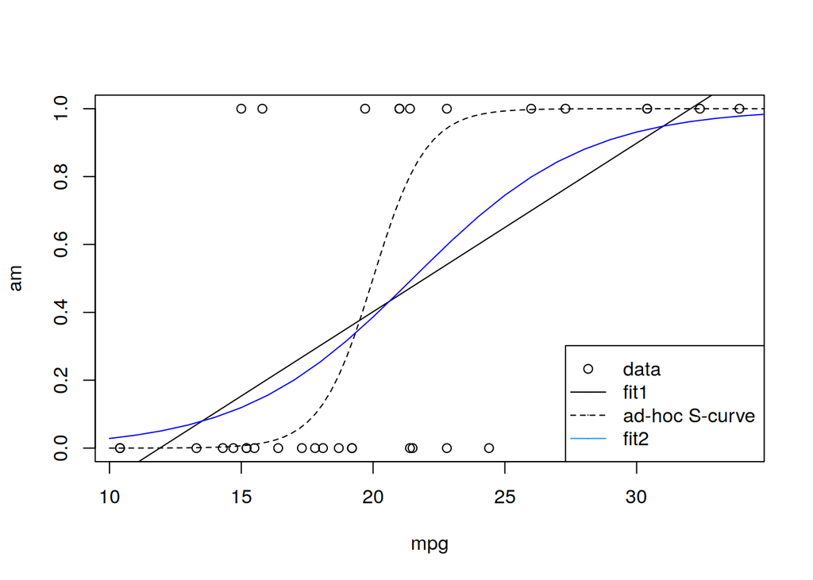

```r
plot(am ~ mpg, data=mtcars)
lines(mtcars$mpg, fit1$fitted.values)
curve(exp(x-20)/(1+exp(x-20)), from=10, to=40, add=T, lty=2)
lines(10:35, pred2, col="blue")
legend("bottomright", legend=c("data", "fit1", "ad-hoc S-curve", "fit2"),
       pch=c(1, 46,46,46), lty=c(0, 1,2,1), col=c(1, 1,1,4)
)
```

Modrá krivka lepšie popisuje pozorované údaje ako čierne krivky.

#### Dva prediktory (spojité n.p.)

Pravdepodobnosť konkrétneho typu prevodovky okrem dojazdu súvisí aj so silou motora, preto model obsahujúci *hp* bude lepšie popisovať pozorované údaje. Analýza rozptylu má inú formu, než pri bežnom lineárnom modeli, rozdiel v schopnostiach modelov je reprezentovaný rozdielom reziduálnych deviancií

```r
( fit3 <- glm(am ~ mpg + hp, data = mtcars, family = binomial(link="logit")) )
```

```
##
## Call:  glm(formula = am ~ mpg + hp, family = binomial(link = "logit"),
##     data = mtcars)
##
## Coefficients:
## (Intercept)          mpg           hp
##   -33.60517      1.25961      0.05504
##
## Degrees of Freedom: 31 Total (i.e. Null);  29 Residual
## Null Deviance:       43.23
## Residual Deviance: 19.23     AIC: 25.23
```

```r
anova(fit2, fit3, test = "Chisq")
```

```
## Analysis of Deviance Table
##
## Model 1: am ~ mpg
## Model 2: am ~ mpg + hp
##   Resid. Df Resid. Dev Df Deviance Pr(>Chi)
## 1        30     29.675
## 2        29     19.233  1   10.443 0.001231 **
## ---
## Signif. codes:  0 '***' 0.001 '**' 0.01 '*' 0.05 '.' 0.1 ' ' 1
```

Zobrazenie 2D

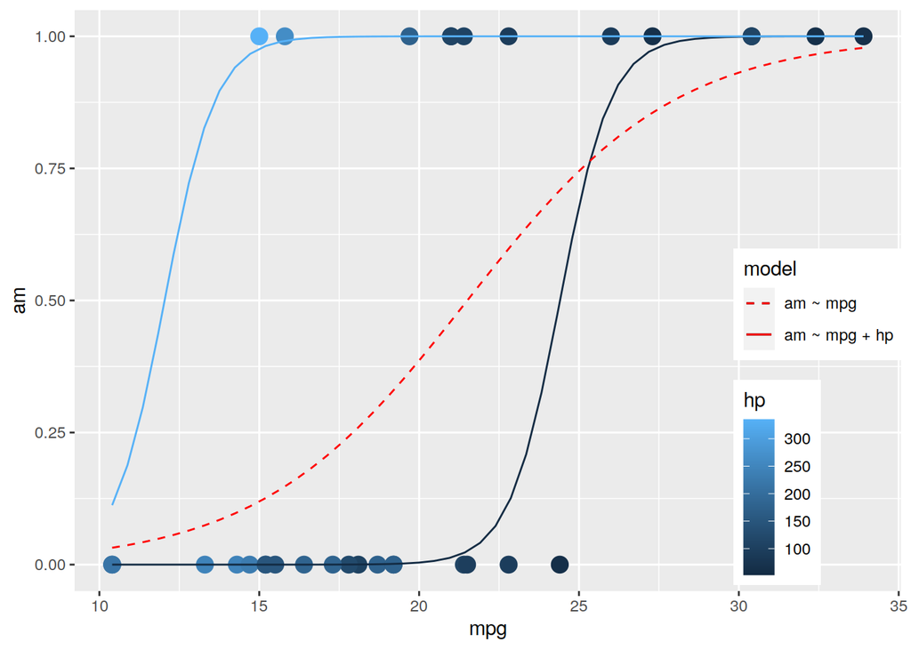

```r
newmpg <- with(mtcars, seq(min(mpg), max(mpg), length.out=50))
newhp <- range(mtcars$hp)
pred3 <- lapply(newhp, function(x) {
  df <- data.frame(mpg=newmpg, hp=x)
  cbind(df, am = predict.glm(fit3, newdata = df, type="response"))
})
pred3 <- do.call(rbind, pred3)
pred2 <- local({
  df = data.frame(mpg = newmpg)
  cbind(df, am = predict.glm(fit2, newdata = df, type="response"))
})
ggplot(data=mtcars, mapping=aes(x=mpg, y=am)) + geom_point(aes(color=hp), size=4) +
  geom_line(data=pred3, mapping=aes(group=hp, color=hp, linetype="am ~ mpg + hp")) +
  geom_line(data=pred2, aes(linetype="am ~ mpg"), color="red") +
  scale_linetype_manual(values = c("dashed", "solid")) + labs(linetype = "model") +
  theme(legend.position = c(0.9, 0.3))  # legend.position = "right"
```

Zobrazenie 3D

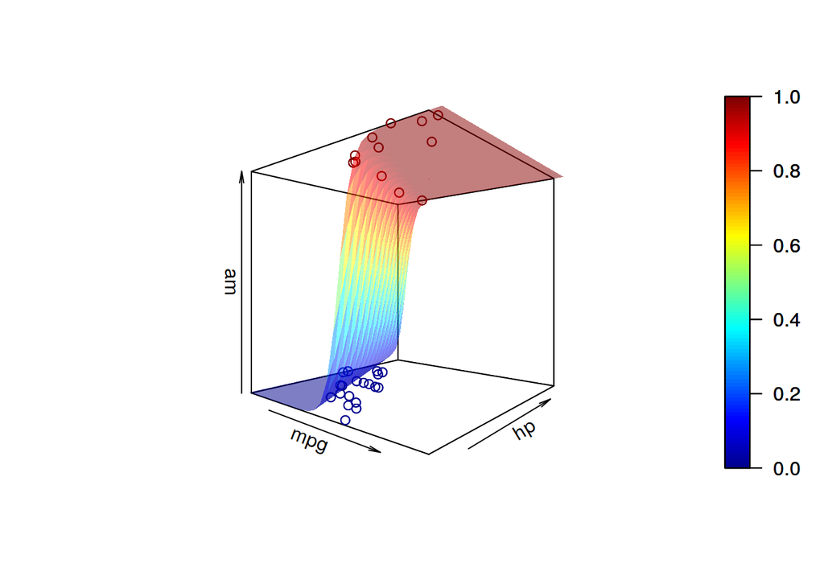

```r
n <- 30
grid <- list(mpg=seq(10,35,length.out=n), hp=seq(52,335, length.out=n))
grid_exp <- expand.grid(grid$mpg, grid$hp)
grid_exp <- 'names<-'(as.data.frame(grid_exp),c("mpg","hp"))
grid$am <- predict(fit3, newdata = grid_exp, type="response")
grid$am <- matrix(grid$am, nrow=n, byrow = F)


with(mtcars, {
  plot3D::points3D(x=mpg, y=hp, z=am, phi=0, add=F, xlab="mpg", ylab="hp", zlab="am");
})
with(grid, {
  plot3D::persp3D(x=mpg, y=hp, z=am, phi=0, add=T, alpha=0.3)
})
```

```r
# pozri napr. https://newonlinecourses.science.psu.edu/stat501/node/374/
# https://bookdown.org/egarpor/SSS2-UC3M/logreg-deviance.html
```

### Odozva je viac-hodnotová premenná

Rozšírenie počtu hodnôt (kategórií) odozvy oproti dvom so sebou prináša viacero možností:

1. odozva je nominálna premenná = hodnoty nemajú vnútorné radenie (príkladom sú farba, krajina, rasa a pod.)
2. odozva je ordinálna premenná = hodnoty majú definované poradie (ordinálnou sa stane aj každá nominálna, ktorej priradíme poradie, napr. farba, ak nás zaujíma jej fyzikálna podstata)
3. odozva má definované poradie a známe rozdelenie pravdepodobnosti (napr. počet)

Štatistické metódy, ktoré fungujú s prvou (druhou) možnosťou, budú fungovať aj s nasledujúcimi (možnosti sú zoradené hierarchicky pridávaním ďalších vlastností), ale je výhodnejšie vždy použiť špecializovanejšiu metódu, ak je to možné, aby sa využili všetky dostupné informácie.

#### Nominálna

Na modelovanie závislosti nominálnej náhodnej premennej od prediktorov ľubovoľného typu sa používajú dve zásadne odlišné štatistické metódy:

- *multinomial logistic regression* zovšeobecňuje logistickú regresiu
- *linear discriminant analysis* (LDA) modeluje rozdelenie prediktorov podľa úrovní odozvy

LDA si ilustrujeme až pri ordinálnej odozve v ďalšej podkapitole.

##### Multinomial logistic regresion

MLR rozdelí problém na niekoľko logistických regresných modelov, každý na odhad pravdepodobnosti nastatia jednej z hodnôt odozvy oproti referenčnej, napr. poslednej $\log\frac{Pr(Y=y_j)}{Pr(Y=y_k)} = \beta_0 + \beta_1 X_1 + \ldots$, kde $j = 1,\ldots,k-1$. Každý model má svoj absolútny člen a regresné koeficienty (čiže prediktory ovplyvňujú nastatie každej kategórie zvlášť).

**Príklad** (iris dataset)

Z dĺžky a šírky kalíšnych (sepal) a korunných (petal) lupeňov kvetov odhadnite druh kosatca (iris).

*Riešenie:*  
Dáta si najprv zobrazíme

```r
str(iris)
```

```
## 'data.frame':    150 obs. of  5 variables:
##  $ Sepal.Length: num  5.1 4.9 4.7 4.6 5 5.4 4.6 5 4.4 4.9 ...
##  $ Sepal.Width : num  3.5 3 3.2 3.1 3.6 3.9 3.4 3.4 2.9 3.1 ...
##  $ Petal.Length: num  1.4 1.4 1.3 1.5 1.4 1.7 1.4 1.5 1.4 1.5 ...
##  $ Petal.Width : num  0.2 0.2 0.2 0.2 0.2 0.4 0.3 0.2 0.2 0.1 ...
##  $ Species     : Factor w/ 3 levels "setosa","versicolor",..: 1 1 1 1 1 1 1 1 1 1 ...
```

`Species` je naša odozva, nadobúda tri hodnoty (kategórie), ostatné stĺpce predstavujú prediktory. Graficky:

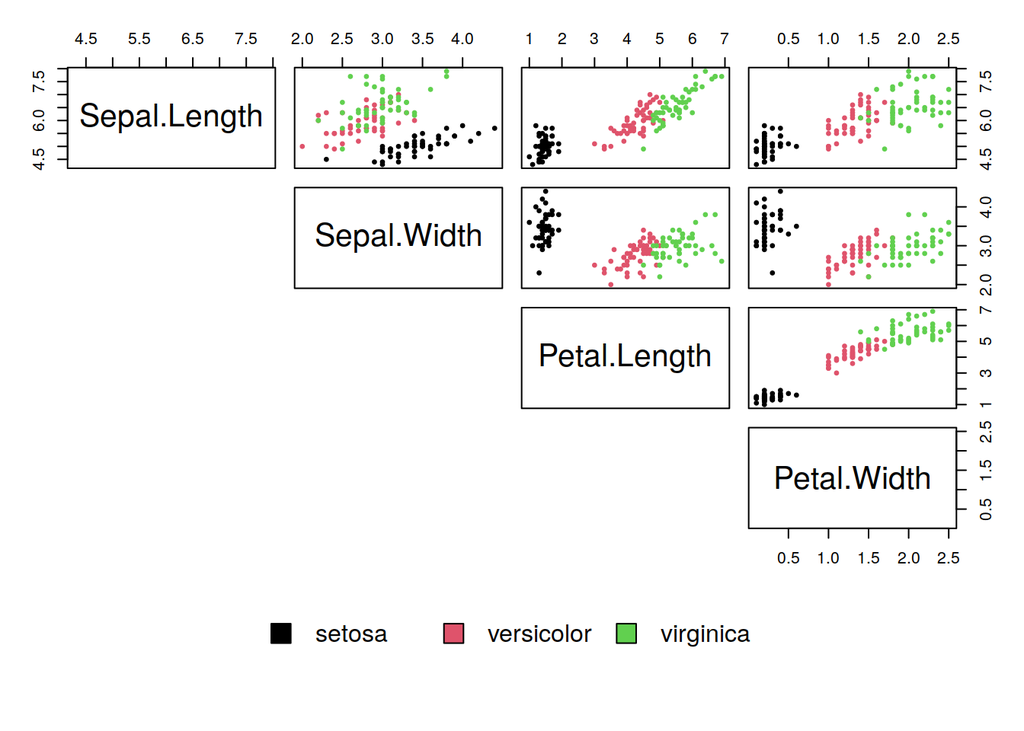

```r
pairs(iris[,1:4], pch = 19,  cex = 0.5, oma = c(10,3,3,3),
      col = iris$Species,
      lower.panel=NULL)
legend("bottom", legend = levels(iris$Species),
       fill = unique(iris$Species), horiz = T, xpd = TRUE, bty = 'n')
```

Jednotlivé druhy sa (v zmysle týchto 4 vlastností) od seba pomerne zreteľne odlišujú, model by teda mal mať po natrénovaní (t.j. odhadnutí parametrov) dobrú klasifikačnú schopnosť. Jedna z metód odhadu parametrov MLR využíva neurónové siete z predinštalovaného balíku *nnet*:

```r
fit <- nnet::multinom(Species ~., data = iris)
summary(fit)
```

```
## Call:
## nnet::multinom(formula = Species ~ ., data = iris)
##
## Coefficients:
##            (Intercept) Sepal.Length Sepal.Width Petal.Length Petal.Width
## versicolor    18.69037    -5.458424   -8.707401     14.24477   -3.097684
## virginica    -23.83628    -7.923634  -15.370769     23.65978   15.135301
##
## Std. Errors:
##            (Intercept) Sepal.Length Sepal.Width Petal.Length Petal.Width
## versicolor    34.97116     89.89215    157.0415     60.19170    45.48852
## virginica     35.76649     89.91153    157.1196     60.46753    45.93406
##
## Residual Deviance: 11.89973
## AIC: 31.89973
```

Intepretácia parametrov je podobná ako pri logistickej regresii, tak napr. šanca, že kvet pochádza z druhu versicolor oproti setosa, je pri kvete s o-jeden-centimeter-dlhším kalíšnym lístkom približne $e^{-5.46}=0.0043$-krát nižšia.  
Predpoveď pomocou generickej funkcie `predict` je podobne jednoduchá ako pri obyčajnej regresii, máme si však možnosť okrem najpravdepodobnejšej triedy

```r
predict(fit, newdata = iris[2,-5], type = "class")
```

```
## [1] setosa
## Levels: setosa versicolor virginica
```

nechať zobraziť aj jednotlivé pravdepodobnosti.

```r
predict(fit, newdata = iris[2,-5], type = "probs")
```

```
##       setosa   versicolor    virginica
## 9.999996e-01 3.536476e-07 2.883729e-32
```

V tomto prípade je predpoveď prakticky jednoznačná a …

```r
iris[2,5]
```

```
## [1] setosa
## Levels: setosa versicolor virginica
```

… správna.

Či je model skutočne dobrý sa dá overiť na základe predpovedných chýb (v prípade klasifikácie - teda na rozdiel od regresnej úlohy) na základe počtu úspešných predpovedí. Dáta sa náhodne rozdelia na trénovaciu a testovaciu vzorku, napr. v pomere 80-20

```r
set.seed(123)
ind <- sample(c(TRUE, FALSE), size = nrow(iris), replace = TRUE, prob = c(0.8, 0.2))
fit <- nnet::multinom(Species ~., data = iris[ind,], trace = FALSE)
pred <- predict(fit, newdata = iris[!ind,-5], type = "class")
mean(pred == iris[!ind,5])
```

```
## [1] 0.9310345
```

93% úspešnosť (accuracy). Okrem *accuracy* poznáme aj ďalšie charakteristiky klasifikačnej schopnosti modelu vychádzajúce z tzv. *confusion matrix*, ako napr. sensitivity, specificity, precision atď. (pozri definície v nápovede alebo v literatúre):

```r
caret::confusionMatrix(iris[!ind,5], pred) # conf.m: table(skutočné = iris[!ind,5], odhadnuté = pred)
```

```
## Confusion Matrix and Statistics
##
##             Reference
## Prediction   setosa versicolor virginica
##   setosa         11          0         0
##   versicolor      0          7         0
##   virginica       0          2         9
##
## Overall Statistics
##
##                Accuracy : 0.931
##                  95% CI : (0.7723, 0.9915)
##     No Information Rate : 0.3793
##     P-Value [Acc > NIR] : 7.016e-10
##
##                   Kappa : 0.8961
##
##  Mcnemar's Test P-Value : NA
##
## Statistics by Class:
##
##                      Class: setosa Class: versicolor Class: virginica
## Sensitivity                 1.0000            0.7778           1.0000
## Specificity                 1.0000            1.0000           0.9000
## Pos Pred Value              1.0000            1.0000           0.8182
## Neg Pred Value              1.0000            0.9091           1.0000
## Prevalence                  0.3793            0.3103           0.3103
## Detection Rate              0.3793            0.2414           0.3103
## Detection Prevalence        0.3793            0.2414           0.3793
## Balanced Accuracy           1.0000            0.8889           0.9500
```

Model sa pomýlil iba pri druhu Virginica, dva krát si kvet pomýlil s Versicolor.

#### Ordinálna

##### Ordinálna (logistická) regresia

Ordinal regression je ďalším z rozšírení logistickej regresie, a využíva zoradenosť úrovní odozvy. Oproti MLR však OLR modeluje šancu, že odozva nadobudne *nanajvýš* určitú hodnotu oproti tomu, že nadobudne *vyššie* hodnoty, teda $\frac{Pr(Y\leq y_j)}{Pr(Y> y_j)}$, kde $j=1,\ldots,k-1$. Model sa tak zvykne označovať aj ako *proportional odds logistic regression*. Každý z *k-1* (logaritmov) pomerov má v lineárnom modeli svoj absolútny člen, no regresné koeficienty pri prediktoroch si zdieľajú (na rozdiel od MLR). Vďaka tomu je model pomerne jednoduchý (v komplikovanejších prípadoch je však možné použiť zovšeobecnený OLR model).

**Príklad**

```r
fit <- mtcars %>%
  dplyr::mutate(cyl = ordered(cyl, sort(unique(cyl)))) %>%
  MASS::polr(formula = as.formula("cyl ~ disp")) %>%
  print()
```

```
## Call:
## MASS::polr(formula = as.formula("cyl ~ disp"), data = .)
##
## Coefficients:
##      disp
## 0.4443344
##
## Intercepts:
##      4|6      6|8
##  64.9643 118.0268
##
## Residual Deviance: 3.924663
## AIC: 9.924663
## Warning: did not converge as iteration limit reached
```

Koeficient sa už ťažšie interpretuje, kladná hodnota však značí rastúci vzťah medzi `disp` a `cyl`. Absolútny člen v tomto prípade nemá zmysluplnú interpretáciu, keďže zdvihový objem nemôže mať nulovú hodnotu.  
Výpočet úplne neskonvergoval, no presnosť pomocou summary(fit) je aj tak iba orientačná (preto funkcia ani nepočíta p-hodnotu) - prediktor `disp` vychádza ako nevýznamný. Model je však užitočný, čo vidieť aj z grafu:

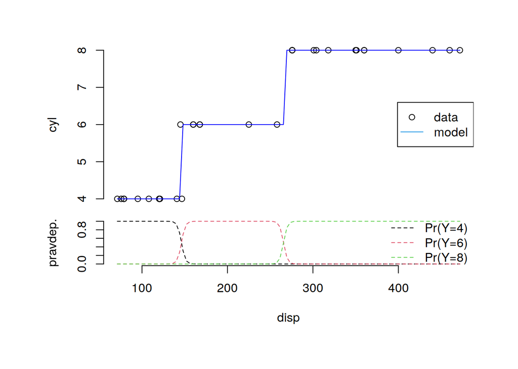

```r
xnew <- seq(min(mtcars$disp), max(mtcars$disp), length.out = 100)
layout(rbind(1,2), heights = c(5,3))
old <- par(oma=c(3, 3, 3, 3), mar=c(1, 4, 0, 0))
plot(cyl ~ disp, mtcars, axes=F)
lines(x = xnew,
      y = as.numeric(as.character(predict(fit, newdata = list(disp = xnew)))),
      col = "blue")
legend("right", c("data","model"), lty=c(NA,1), col=c(1,4), pch = c(1,NA))
axis(2); par(mar=c(4, 4, 0, 0))
matplot(xnew, predict(fit, newdata = list(disp = xnew), type = "p"),
        xlab = "disp", ylab = "pravdep.", type= "l", lty = 2, axes = F)
legend("right", c("Pr(Y=4)","Pr(Y=6)","Pr(Y=8)"), lty=2, col=1:3, bty="n")
axis(1); axis(2)
```

```r
layout(rbind(1))
par(old)
```

Výpočet pravdepodobností pre X = 150:  
$logit[Pr(Y≤4)] = \log\frac{Pr(Y≤4)}{1-Pr(Y≤4)} = 64.964 - 0.4443*150 = -1.681$  
$Pr(Y=4) = Pr(Y≤4) = \frac{exp(-1.685)}{1+exp(-1.685)} = 0.1570$  
$logit[Pr(Y≤6)] = \log\frac{Pr(Y≤6)}{1-Pr(Y≤6)} = 118.027 - 0.4443*150 = 51.382$  
$Pr(Y≤6) = \frac{exp(51.382)}{1+exp(51.382)} = 1$  
$Pr(Y=6) = Pr(Y≤6) - Pr(Y≤4) = 1 - 0.1570 = 0.843$  
$Pr(Y=8) = 1 - Pr(Y≤6) = 0$

```r
predict(fit, newdata = list(disp = 150), type = "p")
```

```
##         4         6         8
## 0.1563213 0.8436787 0.0000000
```

```r
# https://www.benjaminbell.co.uk/2018/02/creating-multi-panel-plots-and-figures.html
```

##### Lineárna diskriminačná analýza

LDA je štatistická metóda, ktorá hľadaním vhodnej lineárnej kombinácie prediktorov $X_1,...,X_n$ dokáže rozlíšiť triedy závislej premennej *A*.

Zatiaľčo logistická regresia modeluje priamo podmienené rozdelenie pravdepodobnosti binárnej premennej *A*, teda $Pr(A = k|X_1 = x_1,...,X_n=x_n)$, a to pomocou logistickej link funkcie, metóda LDA na to ide nepriamo: modeluje (podmienené) rozdelenie pravdepodobnosti prediktorov zvlášť pre každú triedu odozvy *A*, aby z nich vzápätí pomocou Bayesovej vety dostala $Pr(A = k|X_1...)$. V prípade normálneho rozdelenia je model LDA veľmi podobný logistickej regresii.

###### Jeden prediktor

Budeme modelovať počet valcov v závislosti od dojazdu.

```r
( fit1 <- MASS::lda(cyl ~ mpg, data = mtcars) )
```

```
## Call:
## lda(cyl ~ mpg, data = mtcars)
##
## Prior probabilities of groups:
##       4       6       8
## 0.34375 0.21875 0.43750
##
## Group means:
##        mpg
## 4 26.66364
## 6 19.74286
## 8 15.10000
##
## Coefficients of linear discriminants:
##           LD1
## mpg 0.3102604
```

“Prior probabilities” sú relatívne početnosti pozorovaní v jednotlivých triedach, “group means” priemery prediktorov a “coeficients” … sú koeficienty lineárnej kombinácie ktorými sa z prediktorov vyskladajú lineárne diskriminanty (podobne ako pri analýze hlavných komponentov), v našom prípade iba jeden. Pozrime sa na rozdelenie prediktoru *mpg* najprv bez ohľadu a potom s ohľadom na triedy *cyl*.

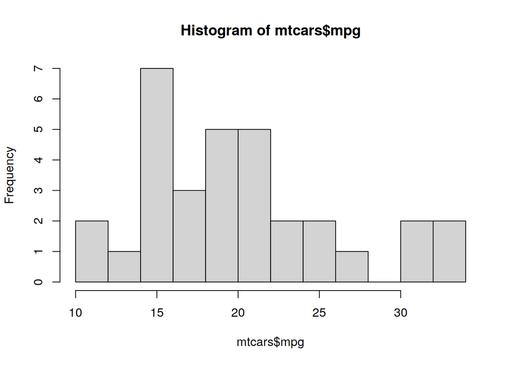

```r
hist(mtcars$mpg, breaks=10)
```

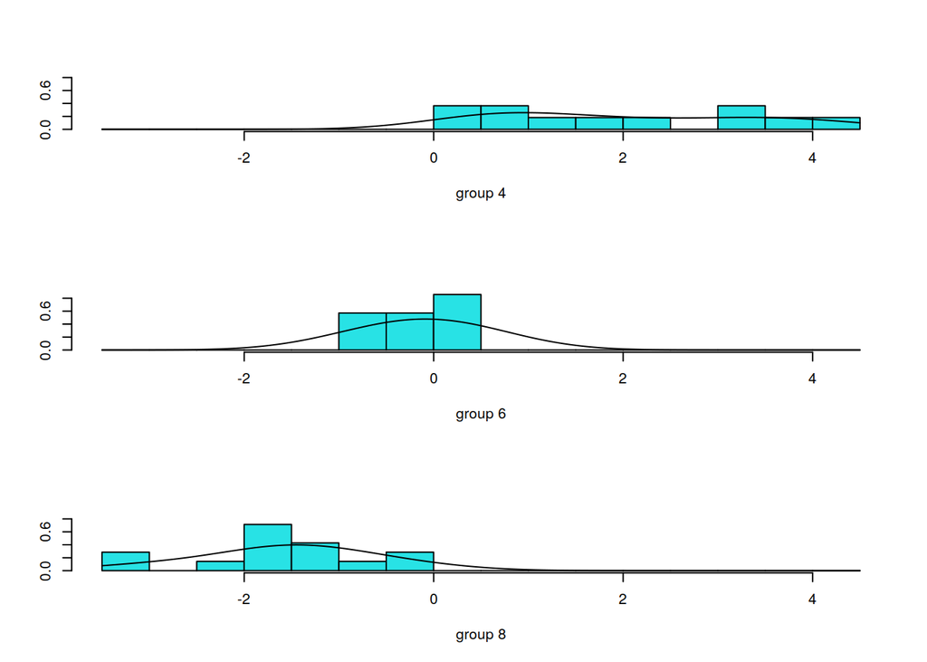

```r
MASS::ldahist(data = predict(fit1)$x[,1], g = mtcars$cyl, type="both")
```

Na osi x je preškálované *mpg* (centrované a vynásobené LDA koeficientom), vidieť rozdiely medzi triedami.  
Predpovede sa vykonajú rovnako ako predtým.

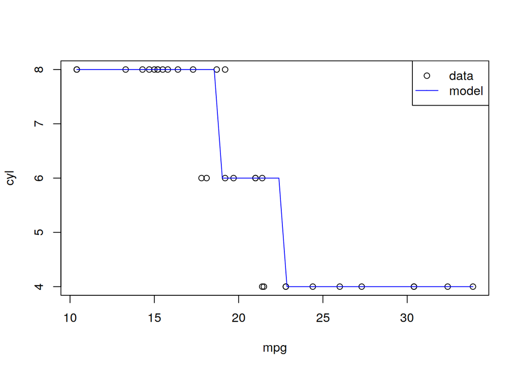

```r
newmpg <- with(mtcars, seq(min(mpg), max(mpg), length.out=50))
pred <- predict(fit1, newdata = data.frame(mpg = newmpg))
plot(cyl ~ mpg, data = mtcars, xlab="mpg", ylab="cyl")
lines(newmpg, as.numeric(as.character(pred$class)), col="blue")
legend("topright", c("data", "model"), pch=c(1,46), lty=c(0,1), col=c("black","blue"))
```

###### Viac prediktorov

Vizualizácia pozorovaní pre každú uvažovanú dvojicu prediktorov, *cyl* je stále odozva:

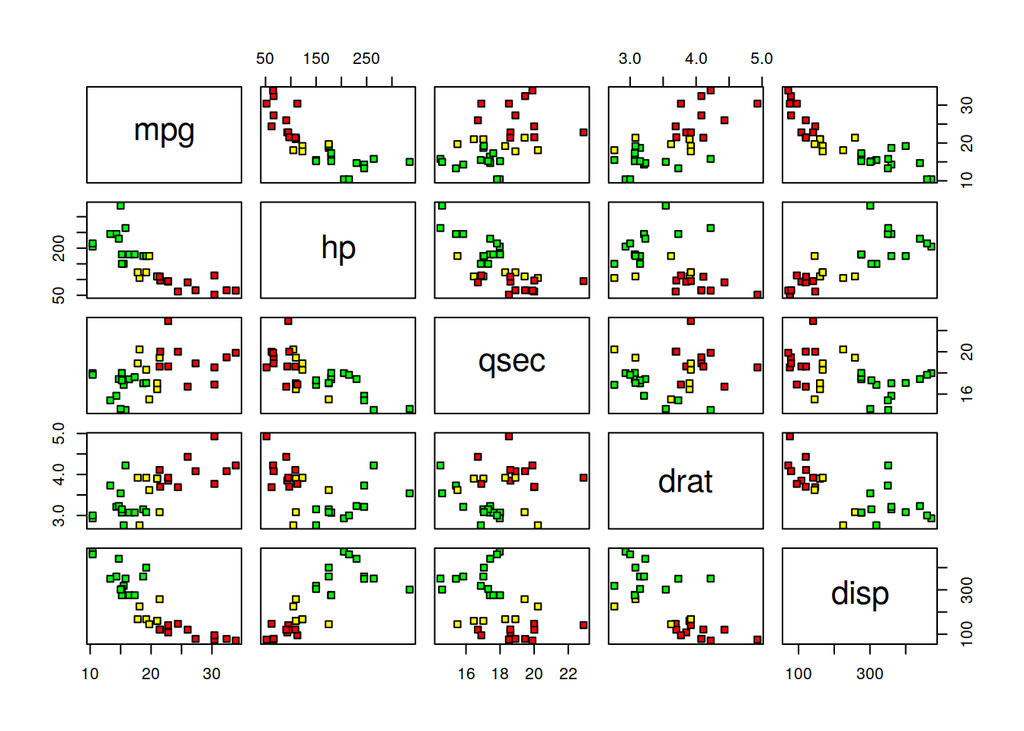

```r
pairs(mtcars[c("mpg", "hp", "qsec", "drat", "disp")],
      pch = 22, bg = c("red", "yellow", "green")[unclass(as.factor(mtcars$cyl))]
)
```

Nie každá dvojica má pekne odseparované údaje podľa počtu cylindrov.  
Model:

```r
( fit2 <- MASS::lda(cyl ~ mpg + hp + qsec + drat + disp, data = mtcars) )
```

```
## Call:
## lda(cyl ~ mpg + hp + qsec + drat + disp, data = mtcars)
##
## Prior probabilities of groups:
##       4       6       8
## 0.34375 0.21875 0.43750
##
## Group means:
##        mpg        hp     qsec     drat     disp
## 4 26.66364  82.63636 19.13727 4.070909 105.1364
## 6 19.74286 122.28571 17.97714 3.585714 183.3143
## 8 15.10000 209.21429 16.77214 3.229286 353.1000
##
## Coefficients of linear discriminants:
##               LD1        LD2
## mpg  -0.053911913 0.30987233
## hp    0.006569312 0.01741887
## qsec -0.426460202 0.42828859
## drat -1.293953494 0.92898019
## disp  0.012904432 0.01206597
##
## Proportion of trace:
##    LD1    LD2
## 0.9654 0.0346
```

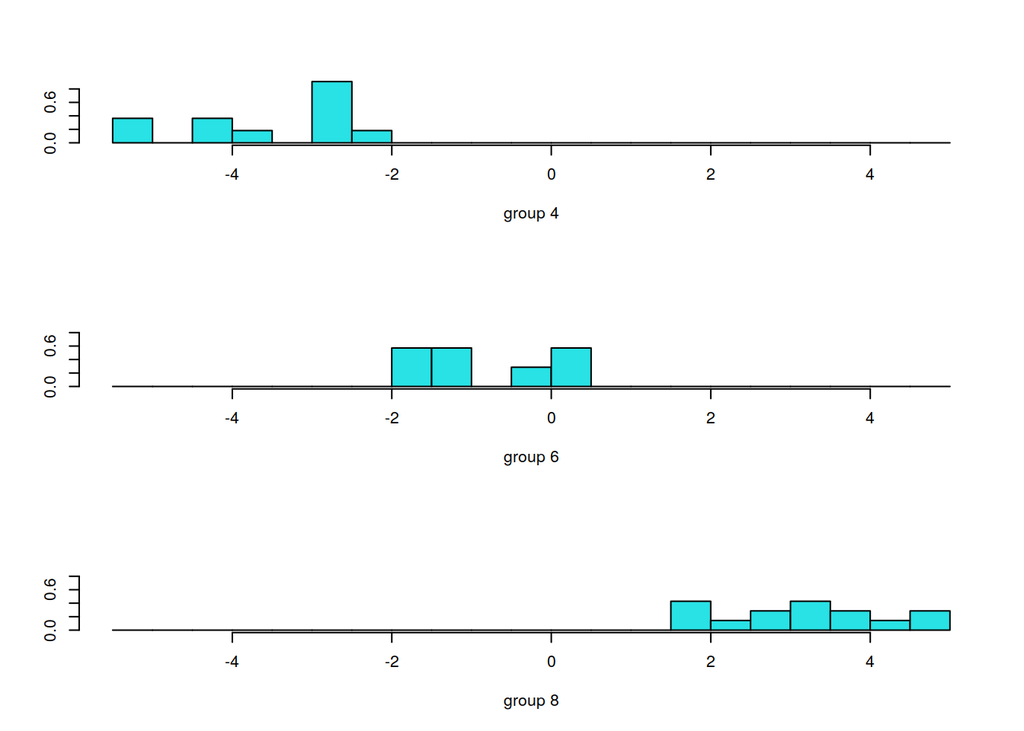

```r
MASS::ldahist(data = predict(fit2)$x[,1], g = mtcars$cyl)
```

Teraz sa už hodnoty na osi x nedajú tak ľahko interpretovať, pretože sú lineárnou kombináciou viacerých prediktorov, ale rozdiel medzi skupinami je výraznejší. Miera separácie sa dá určiť aj z grafu prvých dvoch diskriminantov.

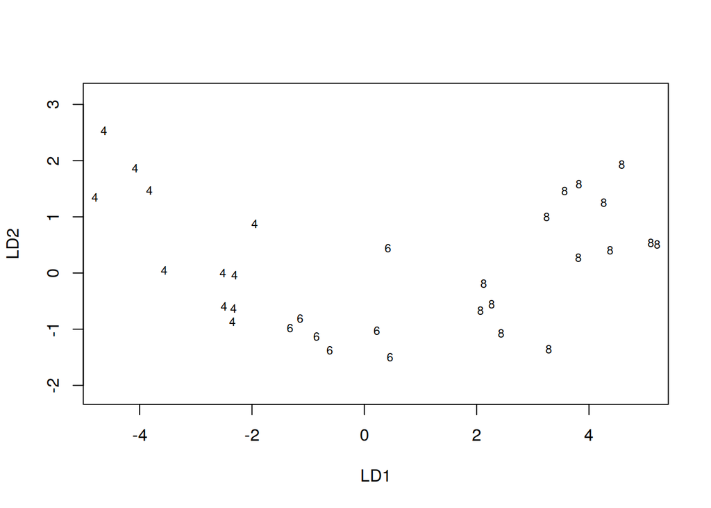

```r
plot(fit2)
```

Detailný pohľad na zastúpenie konkrétnych prediktorov a ich predpovednú hodnotu pre určenie triedy (počtu valcov):

```r
klaR::partimat(as.factor(cyl) ~ mpg + hp + qsec + drat + disp,
               data = mtcars,
               method = "lda"
)
```

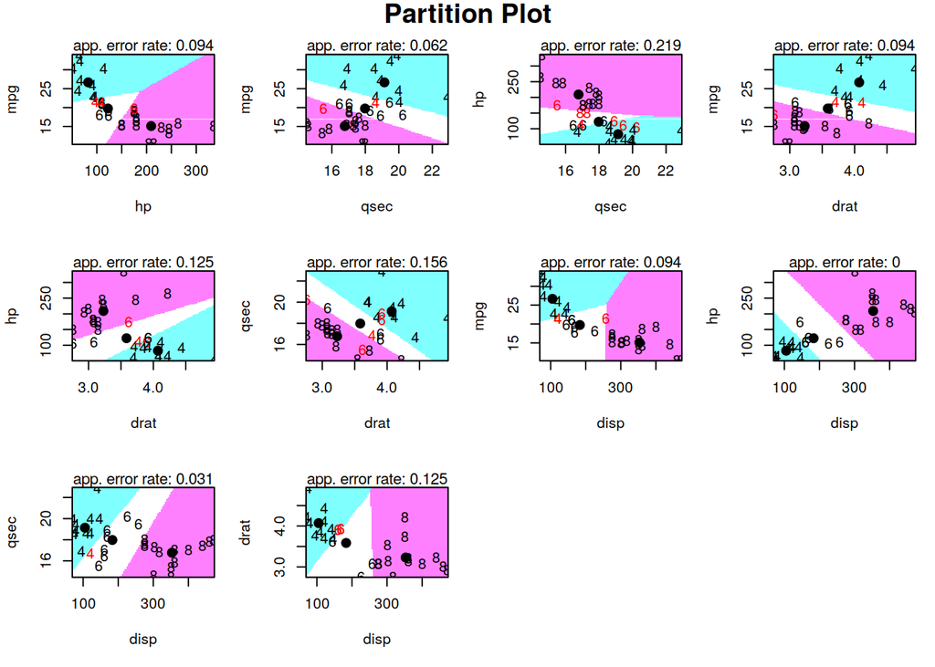

Výstup obsahuje chybovosť modelu, roviny diskriminácie, ťažisko skupiny a nesprávne určené cyl.

```r
# Pozri napr. https://towardsdatascience.com/classification-part-2-linear-discriminant-analysis-ea60c45b9ee5

# https://www.r-bloggers.com/computing-and-visualizing-lda-in-r/
```

##### Veľa hodnôt, viazané poradím, typické rozdelenie

Príkladom diskrétnej premennej je aj počet (napr. výskytu nejakého rastlinného/živočíšneho druhu, alebo javu). Taká premenná je zjavne ohraničená nulou a jej rozdelenie je často zošikmené sprava. Na jeho popis sa používa Poissonovo rozdelenie, regresia dostala prídavné meno Poissonova a patrí do triedy zovšeobecneného lineárneho modelu, štandardne s logaritmickou link funkciou.

Modelujme napríklad počet chýb pozorovaných na priadzi určitej dĺžky podľa typu vlny a úrovne napnutia na stroji.

```r
str(warpbreaks)
```

```
## 'data.frame':    54 obs. of  3 variables:
##  $ breaks : num  26 30 54 25 70 52 51 26 67 18 ...
##  $ wool   : Factor w/ 2 levels "A","B": 1 1 1 1 1 1 1 1 1 1 ...
##  $ tension: Factor w/ 3 levels "L","M","H": 1 1 1 1 1 1 1 1 1 2 ...
```

```r
fit <- glm(breaks ~ wool + tension, warpbreaks, family = quasipoisson(link = "log"))
summary(fit)
```

```
##
## Call:
## glm(formula = breaks ~ wool + tension, family = quasipoisson(link = "log"),
##     data = warpbreaks)
##
## Deviance Residuals:
##     Min       1Q   Median       3Q      Max
## -3.6871  -1.6503  -0.4269   1.1902   4.2616
##
## Coefficients:
##             Estimate Std. Error t value Pr(>|t|)
## (Intercept)  3.69196    0.09374  39.384  < 2e-16 ***
## woolB       -0.20599    0.10646  -1.935 0.058673 .
## tensionM    -0.32132    0.12441  -2.583 0.012775 *
## tensionH    -0.51849    0.13203  -3.927 0.000264 ***
## ---
## Signif. codes:  0 '***' 0.001 '**' 0.01 '*' 0.05 '.' 0.1 ' ' 1
##
## (Dispersion parameter for quasipoisson family taken to be 4.261537)
##
##     Null deviance: 297.37  on 53  degrees of freedom
## Residual deviance: 210.39  on 50  degrees of freedom
## AIC: NA
##
## Number of Fisher Scoring iterations: 4
```

```r
predict(fit, newdata = list(wool = "B", tension = "L"), type = "response")
```

```
##        1
## 32.65424
```

Vizualizácia pozorovaní a predikcie:

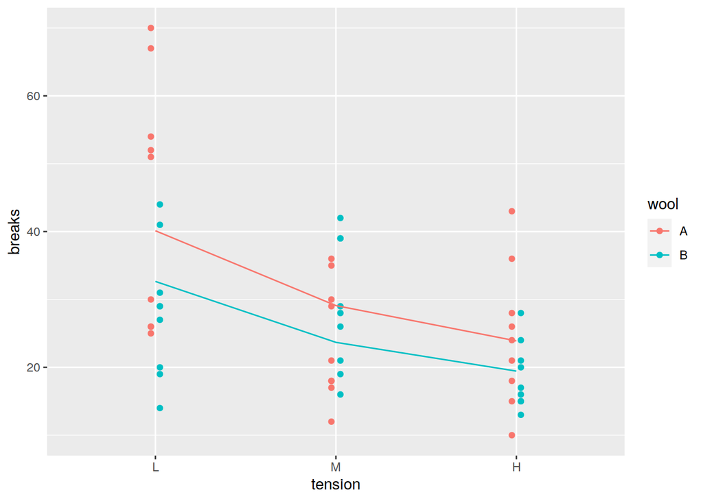

```r
tmp <- unique(warpbreaks[2:3]) %>%
  cbind(., model = predict(fit, newdata = ., type = "response"))
ggplot(warpbreaks, aes(x = tension, y = breaks, color = wool, group = wool)) + geom_jitter(position = position_dodge(width=0.1)) + geom_line(data = tmp, aes(y = model))
```

Poissonovo rozdelenie má strednú hodnotu rovnú disperzii. Všimnime si ešte v textovom výstupe odhadu modelu, že nulová a reziduálna deviancia sú podstatne väčšie ako počet stupňov voľnosti (degrees of freedom), čo naznačuje, že naše dáta majú rozptyl väčší ako strednú hodnotu (jav známy ako *overdispersion*) a teda Poissonovo rozdelenie zrejme nie je najlepšie na ich popis. Na samotné bodové predpovede to nemá významný vplyv, nepresné sú však odhady štandardných chýb a z toho plynúce testy významnosti parametrov modelu. Ako náhrada sa používa kvázi-Poissonovo (`family = "quasipoisson"`), alebo negatívne binomické rozdelenie (`funkcia MASS::glm.nb`). Zvláštne prípady, ako napr., že dáta obsahujú veľa nulových hodnôt (zero-inflated) riešia ďalšie metódy a balíky v R, pozri prehľad na stránke https://rcompanion.org/handbook/J_01.html.

Zovšeobecnený lineárny model vie okrem uvedených metód – a ako špeciálny prípad aj obyčajný lineárny model (`family = gaussian(link="identity")`) – obsiahnuť i regresiu, kde odozva je z intervalu `[0,1]` ako je napr. percento alebo pomer nejakej zložky, či čas čakania alebo čas medzi dvoma zlyhaniami, podiel nehôd a pod., to sú však už spojité náhodné premenné. Na všetky regresné a klasifikačné úlohy GLM využíva rozdelenia (diskrétne i spojité) z exponenciálnej triedy rozdelení (https://en.wikipedia.org/wiki/Exponential_family).

# Odporúčaná literatúra

- Dalpiaz 2018: Applied Statistics with R
- James, Witten, Hastie, Tibshirani 2013: An Introduction to Statistical Learning with Applications in R
- Kalina a kol. 2010: Základy pravdepodobnosti a matematickej štatistiky
- Markechová a kol. 2011b - Štatistické metódy a ich aplikácie (https://www.researchgate.net/profile/Dagmar_Markechova)
- Verzani: Simple R